# Visualizing FordGoBike Data (2018)

## by Satyaraj Reddy

- Introduction
- Part I - Gathering Data
- Part II - Assessing Data
- Part III - Cleaning Data
- Part IV - Univariate Exploration
- Part V - Bivariate Exploration
- Part VI - Multivariate Exploration

## Introduction

Ford GoBike is a regional public bicycle sharing system in the San Francisco Bay Area, California. Beginning operation in August 2013 as Bay Area Bike Share, the Ford GoBike system currently has over 2,600 bicycles in 262 stations across San Francisco, East Bay and San Jose. On June 28, 2017, the system officially launched as Ford GoBike in a partnership with Ford Motor Company.

Ford GoBike, like other bike share systems, consists of a fleet of specially designed, sturdy and durable bikes that are locked into a network of docking stations throughout the city. The bikes can be unlocked from one station and returned to any other station in the system, making them ideal for one-way trips. The bikes are available for use 24 hours/day, 7 days/week, 365 days/year and riders have access to all bikes in the network when they become a member or purchase a pass.

## Preliminary Wrangling

This document explores the Ford GoBike's trip data for public containing rides from Jan 2018 to Dec 2018.

## Part I - Gathering Data

```python
import numpy as np
import pandas as pd
import matplotlib.pyplot as plt
import seaborn as sns
import datetime
import glob
import os

%matplotlib inline
```

**Firstly, I saved all the csv files from the FordGoBike website in a folder. After this, I used the glob and os modules to combine all the files into a single file fordgobike.csv**

```python
path = r'G:\Udacity Nanodegree\Projects\Data Visualization\FordGoBikeData'
```

```python
all_files = glob.glob(os.path.join(path, "*.csv"))
```

```python
df = pd.concat((pd.read_csv(f) for f in all_files), ignore_index = True)
```

```python
df.to_csv('fordgobike.csv', index = False)
```

## Part II - Assessing Data

```python
df = pd.read_csv('fordgobike.csv')
df.head()
```

|  | duration_sec | start_time | end_time | start_station_id | start_station_name | start_station_latitude | start_station_longitude | end_station_id | end_station_name | end_station_latitude | end_station_longitude | bike_id | user_type | member_birth_year | member_gender | bike_share_for_all_trip |
| --- | --- | --- | --- | --- | --- | --- | --- | --- | --- | --- | --- | --- | --- | --- | --- | --- |
| 0 | 75284 | 2018-01-31 22:52:35.2390 | 2018-02-01 19:47:19.8240 | 120.0 | Mission Dolores Park | 37.761420 | -122.426435 | 285.0 | Webster St at O'Farrell St | 37.783521 | -122.431158 | 2765 | Subscriber | 1986.0 | Male | No |
| 1 | 85422 | 2018-01-31 16:13:34.3510 | 2018-02-01 15:57:17.3100 | 15.0 | San Francisco Ferry Building (Harry Bridges Pl... | 37.795392 | -122.394203 | 15.0 | San Francisco Ferry Building (Harry Bridges Pl... | 37.795392 | -122.394203 | 2815 | Customer | NaN | NaN | No |
| 2 | 71576 | 2018-01-31 14:23:55.8890 | 2018-02-01 10:16:52.1160 | 304.0 | Jackson St at 5th St | 37.348759 | -121.894798 | 296.0 | 5th St at Virginia St | 37.325998 | -121.877120 | 3039 | Customer | 1996.0 | Male | No |
| 3 | 61076 | 2018-01-31 14:53:23.5620 | 2018-02-01 07:51:20.5000 | 75.0 | Market St at Franklin St | 37.773793 | -122.421239 | 47.0 | 4th St at Harrison St | 37.780955 | -122.399749 | 321 | Customer | NaN | NaN | No |
| 4 | 39966 | 2018-01-31 19:52:24.6670 | 2018-02-01 06:58:31.0530 | 74.0 | Laguna St at Hayes St | 37.776435 | -122.426244 | 19.0 | Post St at Kearny St | 37.788975 | -122.403452 | 617 | Subscriber | 1991.0 | Male | No |

```python
df.sample(25)
```

|  | duration_sec | start_time | end_time | start_station_id | start_station_name | start_station_latitude | start_station_longitude | end_station_id | end_station_name | end_station_latitude | end_station_longitude | bike_id | user_type | member_birth_year | member_gender | bike_share_for_all_trip |
| --- | --- | --- | --- | --- | --- | --- | --- | --- | --- | --- | --- | --- | --- | --- | --- | --- |
| 1331781 | 596 | 2018-09-12 09:04:13.0590 | 2018-09-12 09:14:09.4110 | 67.0 | San Francisco Caltrain Station 2 (Townsend St... | 37.776639 | -122.395526 | 58.0 | Market St at 10th St | 37.776619 | -122.417385 | 1273 | Subscriber | 1981.0 | Male | No |
| 1125151 | 465 | 2018-08-14 18:03:30.6610 | 2018-08-14 18:11:15.9700 | 66.0 | 3rd St at Townsend St | 37.778742 | -122.392741 | 21.0 | Montgomery St BART Station (Market St at 2nd St) | 37.789625 | -122.400811 | 2080 | Subscriber | 1981.0 | Male | No |
| 216621 | 444 | 2018-03-28 16:39:33.2990 | 2018-03-28 16:46:58.1480 | 58.0 | Market St at 10th St | 37.776619 | -122.417385 | 90.0 | Townsend St at 7th St | 37.771058 | -122.402717 | 3303 | Subscriber | 1983.0 | Male | No |
| 329060 | 2356 | 2018-04-27 13:31:33.3780 | 2018-04-27 14:10:50.1330 | 123.0 | Folsom St at 19th St | 37.760594 | -122.414817 | 81.0 | Berry St at 4th St | 37.775880 | -122.393170 | 3937 | Subscriber | 1996.0 | Male | Yes |
| 700730 | 626 | 2018-06-19 17:43:31.2230 | 2018-06-19 17:53:57.5610 | 148.0 | Horton St at 40th St | 37.829705 | -122.287610 | 214.0 | Market St at Brockhurst St | 37.823321 | -122.275733 | 1398 | Subscriber | 1992.0 | Other | No |
| 781662 | 650 | 2018-06-06 18:23:09.1410 | 2018-06-06 18:33:59.8950 | 67.0 | San Francisco Caltrain Station 2 (Townsend St... | 37.776639 | -122.395526 | 24.0 | Spear St at Folsom St | 37.789677 | -122.390428 | 271 | Subscriber | 1988.0 | Male | No |
| 1365048 | 225 | 2018-09-06 20:18:58.7780 | 2018-09-06 20:22:44.2730 | 183.0 | Telegraph Ave at 19th St | 37.808702 | -122.269927 | 179.0 | Telegraph Ave at 27th St | 37.816073 | -122.267886 | 1953 | Subscriber | 1993.0 | Male | No |
| 1741429 | 2407 | 2018-12-28 18:35:10.9280 | 2018-12-28 19:15:17.9280 | 296.0 | 5th St at Virginia St | 37.325998 | -121.877120 | 296.0 | 5th St at Virginia St | 37.325998 | -121.877120 | 3804 | Subscriber | 1995.0 | Female | Yes |
| 448030 | 283 | 2018-05-31 13:10:46.6540 | 2018-05-31 13:15:29.6570 | 26.0 | 1st St at Folsom St | 37.787290 | -122.394380 | 36.0 | Folsom St at 3rd St | 37.783830 | -122.398870 | 3852 | Subscriber | 1984.0 | Male | No |
| 1275403 | 287 | 2018-09-20 16:39:30.1570 | 2018-09-20 16:44:17.4160 | 88.0 | 11th St at Bryant St | 37.770030 | -122.411726 | 129.0 | Harrison St at 20th St | 37.758862 | -122.412544 | 2063 | Subscriber | 1987.0 | Male | No |
| 1654466 | 554 | 2018-11-14 16:54:04.1200 | 2018-11-14 17:03:18.9550 | 19.0 | Post St at Kearny St | 37.788975 | -122.403452 | 42.0 | San Francisco City Hall (Polk St at Grove St) | 37.778650 | -122.418230 | 310 | Subscriber | 1991.0 | Female | No |
| 919313 | 596 | 2018-07-17 07:58:45.0090 | 2018-07-17 08:08:41.8800 | 81.0 | Berry St at 4th St | 37.775880 | -122.393170 | 8.0 | The Embarcadero at Vallejo St | 37.799953 | -122.398525 | 4302 | Subscriber | 1982.0 | Female | No |
| 85222 | 729 | 2018-01-04 16:39:43.9700 | 2018-01-04 16:51:53.2430 | 93.0 | 4th St at Mission Bay Blvd S | 37.770407 | -122.391198 | 23.0 | The Embarcadero at Steuart St | 37.791464 | -122.391034 | 3397 | Subscriber | 1981.0 | Male | No |
| 913311 | 534 | 2018-07-17 19:43:56.4570 | 2018-07-17 19:52:50.5610 | 80.0 | Townsend St at 5th St | 37.775306 | -122.397380 | 19.0 | Post St at Kearny St | 37.788975 | -122.403452 | 2244 | Subscriber | 1981.0 | Male | No |
| 1528639 | 627 | 2018-10-11 08:39:33.6750 | 2018-10-11 08:50:01.3800 | 312.0 | San Jose Diridon Station | 37.329732 | -121.901782 | 310.0 | San Fernando St at 4th St | 37.335885 | -121.885660 | 1906 | Subscriber | 1963.0 | Female | No |
| 1776390 | 988 | 2018-12-18 20:20:30.3520 | 2018-12-18 20:36:59.0310 | 5.0 | Powell St BART Station (Market St at 5th St) | 37.783899 | -122.408445 | 127.0 | Valencia St at 21st St | 37.756708 | -122.421025 | 676 | Customer | 1982.0 | Other | No |
| 12854 | 396 | 2018-01-29 08:44:08.0080 | 2018-01-29 08:50:44.1230 | 200.0 | 2nd Ave at E 18th St | 37.800214 | -122.253810 | 163.0 | Lake Merritt BART Station | 37.797320 | -122.265320 | 2337 | Subscriber | 1986.0 | Male | No |
| 1251509 | 794 | 2018-09-24 18:03:53.5510 | 2018-09-24 18:17:08.2490 | 299.0 | Bestor Art Park | 37.323678 | -121.874119 | 311.0 | Paseo De San Antonio at 2nd St | 37.333798 | -121.886943 | 2901 | Subscriber | 1994.0 | Male | Yes |
| 1248028 | 716 | 2018-09-25 08:53:44.9270 | 2018-09-25 09:05:41.2050 | 122.0 | 19th St at Mission St | 37.760299 | -122.418892 | 44.0 | Civic Center/UN Plaza BART Station (Market St ... | 37.781074 | -122.411738 | 2237 | Subscriber | 1986.0 | Male | No |
| 333384 | 883 | 2018-04-26 18:02:55.3940 | 2018-04-26 18:17:39.2050 | 9.0 | Broadway at Battery St | 37.798572 | -122.400869 | 321.0 | 5th at Folsom | 37.780146 | -122.403071 | 2856 | Subscriber | 1990.0 | Female | No |
| 1618965 | 253 | 2018-11-26 18:26:53.3970 | 2018-11-26 18:31:07.3370 | 241.0 | Ashby BART Station | 37.852477 | -122.270213 | 168.0 | Alcatraz Ave at Shattuck Ave | 37.849595 | -122.265569 | 1435 | Subscriber | 1990.0 | Female | No |
| 383636 | 617 | 2018-04-16 14:34:36.8280 | 2018-04-16 14:44:53.8990 | 125.0 | 20th St at Bryant St | 37.759200 | -122.409851 | 96.0 | Dolores St at 15th St | 37.766210 | -122.426614 | 231 | Subscriber | 1977.0 | Female | No |
| 746489 | 539 | 2018-06-12 17:19:00.2660 | 2018-06-12 17:28:00.0920 | 27.0 | Beale St at Harrison St | 37.788059 | -122.391865 | 90.0 | Townsend St at 7th St | 37.771058 | -122.402717 | 635 | Subscriber | 1985.0 | Male | No |
| 84148 | 645 | 2018-01-04 20:34:15.0540 | 2018-01-04 20:45:00.2670 | 78.0 | Folsom St at 9th St | 37.773717 | -122.411647 | 5.0 | Powell St BART Station (Market St at 5th St) | 37.783899 | -122.408445 | 2640 | Subscriber | 1978.0 | Female | No |
| 423731 | 389 | 2018-04-05 12:46:58.1560 | 2018-04-05 12:53:27.8360 | 21.0 | Montgomery St BART Station (Market St at 2nd St) | 37.789625 | -122.400811 | 11.0 | Davis St at Jackson St | 37.797280 | -122.398436 | 3581 | Subscriber | 1982.0 | Other | No |

```python
# Let's check out the information of the dataset
df.info(verbose=True,null_counts=True)
```

```
<class 'pandas.core.frame.DataFrame'>
RangeIndex: 1863721 entries, 0 to 1863720
Data columns (total 16 columns):
duration_sec               1863721 non-null int64
start_time                 1863721 non-null object
end_time                   1863721 non-null object
start_station_id           1851950 non-null float64
start_station_name         1851950 non-null object
start_station_latitude     1863721 non-null float64
start_station_longitude    1863721 non-null float64
end_station_id             1851950 non-null float64
end_station_name           1851950 non-null object
end_station_latitude       1863721 non-null float64
end_station_longitude      1863721 non-null float64
bike_id                    1863721 non-null int64
user_type                  1863721 non-null object
member_birth_year          1753003 non-null float64
member_gender              1753354 non-null object
bike_share_for_all_trip    1863721 non-null object
dtypes: float64(7), int64(2), object(7)
memory usage: 227.5+ MB
```

```python
# Let's check out the shape of the data
df.shape
```

```
(1863721, 16)
```

```python
# Let's also get some description for stats figures
df.describe()
```

|  | duration_sec | start_station_id | start_station_latitude | start_station_longitude | end_station_id | end_station_latitude | end_station_longitude | bike_id | member_birth_year |
| --- | --- | --- | --- | --- | --- | --- | --- | --- | --- |
| count | 1.863721e+06 | 1.851950e+06 | 1.863721e+06 | 1.863721e+06 | 1.851950e+06 | 1.863721e+06 | 1.863721e+06 | 1.863721e+06 | 1.753003e+06 |
| mean | 8.573026e+02 | 1.196744e+02 | 3.776678e+01 | -1.223492e+02 | 1.181730e+02 | 3.776690e+01 | -1.223487e+02 | 2.296851e+03 | 1.983088e+03 |
| std | 2.370379e+03 | 1.003976e+02 | 1.057689e-01 | 1.654634e-01 | 1.004403e+02 | 1.056483e-01 | 1.650597e-01 | 1.287733e+03 | 1.044289e+01 |
| min | 6.100000e+01 | 3.000000e+00 | 3.726331e+01 | -1.224737e+02 | 3.000000e+00 | 3.726331e+01 | -1.224737e+02 | 1.100000e+01 | 1.881000e+03 |
| 25% | 3.500000e+02 | 3.300000e+01 | 3.777106e+01 | -1.224114e+02 | 3.000000e+01 | 3.777106e+01 | -1.224094e+02 | 1.225000e+03 | 1.978000e+03 |
| 50% | 5.560000e+02 | 8.900000e+01 | 3.778107e+01 | -1.223974e+02 | 8.800000e+01 | 3.778127e+01 | -1.223971e+02 | 2.338000e+03 | 1.985000e+03 |
| 75% | 8.720000e+02 | 1.860000e+02 | 3.779625e+01 | -1.222865e+02 | 1.830000e+02 | 3.779728e+01 | -1.222894e+02 | 3.333000e+03 | 1.991000e+03 |
| max | 8.636600e+04 | 3.810000e+02 | 4.551000e+01 | -7.357000e+01 | 3.810000e+02 | 4.551000e+01 | -7.357000e+01 | 6.234000e+03 | 2.000000e+03 |

```python
# Let's check for any duplicates in the data
df.duplicated().sum()
```

```
0
```

```python
# Now, let's check for any NaN values in the data
df.isna().sum()
# As you can clearly see, member_birth_year & member_gender along with some of the starting and ending columns have NaN values
```

```
duration_sec                    0
start_time                      0
end_time                        0
start_station_id            11771
start_station_name          11771
start_station_latitude          0
start_station_longitude         0
end_station_id              11771
end_station_name            11771
end_station_latitude            0
end_station_longitude           0
bike_id                         0
user_type                       0
member_birth_year          110718
member_gender              110367
bike_share_for_all_trip         0
dtype: int64
```

### Quality Issues

**Before assessing the data to draw conclusions, there are some quality issues that need to be cleaned.**

- The following columns are not in object format:
  - start_station_id
  - bike_id
  - end_station_id
- Start/end times are not in the timestamp format.
- Member birth is in the float format, but should be converted to integer format.
- Member birthdates have a few inaccurate values(Dates prior to 1900).
- User type, gender and bike_share_for_all_trip can be set to category format.
- We can further enhance the dataset with more details about the time like month, day, hour, weekday.
- We can also calculate age of the user for any further analysis.

## Part III - Cleaning Data

```python
# Creating a copy of the original dataframe for cleaning.
df_clean = df.copy()
```

### Define

**Converting several of the columns to the appropriate data type:**

- Bike ID, start station ID, and end station ID to object format.
- Starting and ending times to the timestamp format.
- User type, gender, and bike share for all to category format.

### Code

```python
# Changing the format to datetime format
df_clean.start_time = pd.to_datetime(df_clean.start_time)
df_clean.end_time = pd.to_datetime(df_clean.end_time)
```

```python
# Changing the user_type, member_gender, and bike_share_for_all_trip to category format
df_clean.user_type=df_clean.user_type.astype('category')
df_clean.member_gender = df_clean.member_gender.astype('category')
df_clean.bike_share_for_all_trip = df_clean.bike_share_for_all_trip.astype('category')
```

```python
# Changing the bike_id, start_station_id, and end_station_id to object format
df_clean.bike_id = df_clean.bike_id.astype(str)
df_clean.start_station_id = df_clean.start_station_id.astype(str)
df_clean.end_station_id = df_clean.end_station_id.astype(str)
```

### Test

```python
df_clean.info(verbose=True, null_counts=True)
```

```
<class 'pandas.core.frame.DataFrame'>
RangeIndex: 1863721 entries, 0 to 1863720
Data columns (total 16 columns):
duration_sec               1863721 non-null int64
start_time                 1863721 non-null datetime64[ns]
end_time                   1863721 non-null datetime64[ns]
start_station_id           1863721 non-null object
start_station_name         1851950 non-null object
start_station_latitude     1863721 non-null float64
start_station_longitude    1863721 non-null float64
end_station_id             1863721 non-null object
end_station_name           1851950 non-null object
end_station_latitude       1863721 non-null float64
end_station_longitude      1863721 non-null float64
bike_id                    1863721 non-null object
user_type                  1863721 non-null category
member_birth_year          1753003 non-null float64
member_gender              1753354 non-null category
bike_share_for_all_trip    1863721 non-null category
dtypes: category(3), datetime64[ns](2), float64(5), int64(1), object(5)
memory usage: 190.2+ MB
```

### Define

**Calculate the age of each member by subtracting their birth year from the current year (2019)**

### Code

```python
# Subtracting the member_birth_year from the current year(2019) to get the current ages of all the members
df_clean['member_age'] = 2019 - df_clean['member_birth_year']
```

### Test

```python
df_clean.head()
```

|  | duration_sec | start_time | end_time | start_station_id | start_station_name | start_station_latitude | start_station_longitude | end_station_id | end_station_name | end_station_latitude | end_station_longitude | bike_id | user_type | member_birth_year | member_gender | bike_share_for_all_trip | member_age |
| --- | --- | --- | --- | --- | --- | --- | --- | --- | --- | --- | --- | --- | --- | --- | --- | --- | --- |
| 0 | 75284 | 2018-01-31 22:52:35.239 | 2018-02-01 19:47:19.824 | 120.0 | Mission Dolores Park | 37.761420 | -122.426435 | 285.0 | Webster St at O'Farrell St | 37.783521 | -122.431158 | 2765 | Subscriber | 1986.0 | Male | No | 33.0 |
| 1 | 85422 | 2018-01-31 16:13:34.351 | 2018-02-01 15:57:17.310 | 15.0 | San Francisco Ferry Building (Harry Bridges Pl... | 37.795392 | -122.394203 | 15.0 | San Francisco Ferry Building (Harry Bridges Pl... | 37.795392 | -122.394203 | 2815 | Customer | NaN | NaN | No | NaN |
| 2 | 71576 | 2018-01-31 14:23:55.889 | 2018-02-01 10:16:52.116 | 304.0 | Jackson St at 5th St | 37.348759 | -121.894798 | 296.0 | 5th St at Virginia St | 37.325998 | -121.877120 | 3039 | Customer | 1996.0 | Male | No | 23.0 |
| 3 | 61076 | 2018-01-31 14:53:23.562 | 2018-02-01 07:51:20.500 | 75.0 | Market St at Franklin St | 37.773793 | -122.421239 | 47.0 | 4th St at Harrison St | 37.780955 | -122.399749 | 321 | Customer | NaN | NaN | No | NaN |
| 4 | 39966 | 2018-01-31 19:52:24.667 | 2018-02-01 06:58:31.053 | 74.0 | Laguna St at Hayes St | 37.776435 | -122.426244 | 19.0 | Post St at Kearny St | 37.788975 | -122.403452 | 617 | Subscriber | 1991.0 | Male | No | 28.0 |

```python
df_clean.info(verbose=True,null_counts=True)
```

```
<class 'pandas.core.frame.DataFrame'>
RangeIndex: 1863721 entries, 0 to 1863720
Data columns (total 17 columns):
duration_sec               1863721 non-null int64
start_time                 1863721 non-null datetime64[ns]
end_time                   1863721 non-null datetime64[ns]
start_station_id           1863721 non-null object
start_station_name         1851950 non-null object
start_station_latitude     1863721 non-null float64
start_station_longitude    1863721 non-null float64
end_station_id             1863721 non-null object
end_station_name           1851950 non-null object
end_station_latitude       1863721 non-null float64
end_station_longitude      1863721 non-null float64
bike_id                    1863721 non-null object
user_type                  1863721 non-null category
member_birth_year          1753003 non-null float64
member_gender              1753354 non-null category
bike_share_for_all_trip    1863721 non-null category
member_age                 1753003 non-null float64
dtypes: category(3), datetime64[ns](2), float64(6), int64(1), object(5)
memory usage: 204.4+ MB
```

### Define

**Clean up the ages of members. As mentioned in the quality issues, there are a few members with the birth year before 1900. These are a few outliers that don't make sense. Since 99% of users are ages 66 and below, I am going to keep users 66 and below.**

### Code

```python
# Mean age of the members if around 36
df_clean.member_age.mean()
```

```
35.91203780027758
```

```python
df_clean.member_age.describe()
```

```
count    1.753003e+06
mean     3.591204e+01
std      1.044289e+01
min      1.900000e+01
25%      2.800000e+01
50%      3.400000e+01
75%      4.100000e+01
max      1.380000e+02
Name: member_age, dtype: float64
```

**As you can see, 75% of the members are under the age of 41**

```python
df_clean.member_age.describe(percentiles=[.99])
```

```
count    1.753003e+06
mean     3.591204e+01
std      1.044289e+01
min      1.900000e+01
50%      3.400000e+01
99%      6.600000e+01
max      1.380000e+02
Name: member_age, dtype: float64
```

**It's clear that around 99% of the members are below the age of 66**

```python
# Only keep the records where age under 66.It automatically removes null values.
df_clean = df_clean.query('member_age <= 66')
```

```python
# Convert the member_age and member_birth_year to integer format
df_clean.member_age = df_clean.member_age.astype(int)
df_clean.member_birth_year = df_clean.member_birth_year.astype(int)
```

### Test

```python
df_clean.sample(10)
```

|  | duration_sec | start_time | end_time | start_station_id | start_station_name | start_station_latitude | start_station_longitude | end_station_id | end_station_name | end_station_latitude | end_station_longitude | bike_id | user_type | member_birth_year | member_gender | bike_share_for_all_trip | member_age |
| --- | --- | --- | --- | --- | --- | --- | --- | --- | --- | --- | --- | --- | --- | --- | --- | --- | --- |
| 278216 | 866 | 2018-03-11 09:34:27.527 | 2018-03-11 09:48:54.049 | 31.0 | Raymond Kimbell Playground | 37.783813 | -122.434559 | 3.0 | Powell St BART Station (Market St at 4th St) | 37.786375 | -122.404904 | 2393 | Subscriber | 1982 | Male | No | 37 |
| 169370 | 1708 | 2018-02-08 15:42:21.784 | 2018-02-08 16:10:50.631 | 231.0 | 14th St at Filbert St | 37.808750 | -122.283282 | 231.0 | 14th St at Filbert St | 37.808750 | -122.283282 | 2966 | Customer | 1988 | Male | No | 31 |
| 1043127 | 741 | 2018-08-28 11:17:14.389 | 2018-08-28 11:29:35.429 | 242.0 | Milvia St at Derby St | 37.860125 | -122.269384 | 253.0 | Haste St at College Ave | 37.866418 | -122.253799 | 3466 | Customer | 1976 | Male | No | 43 |
| 345835 | 695 | 2018-04-24 18:01:52.958 | 2018-04-24 18:13:28.425 | 6.0 | The Embarcadero at Sansome St | 37.804770 | -122.403234 | 17.0 | Embarcadero BART Station (Beale St at Market St) | 37.792251 | -122.397086 | 3690 | Subscriber | 1988 | Female | No | 31 |
| 694045 | 372 | 2018-06-20 16:57:08.495 | 2018-06-20 17:03:21.268 | 19.0 | Post St at Kearny St | 37.788975 | -122.403452 | 44.0 | Civic Center/UN Plaza BART Station (Market St ... | 37.781074 | -122.411738 | 2600 | Subscriber | 1996 | Male | No | 23 |
| 1033105 | 760 | 2018-08-29 18:00:52.369 | 2018-08-29 18:13:33.282 | 21.0 | Montgomery St BART Station (Market St at 2nd St) | 37.789625 | -122.400811 | 77.0 | 11th St at Natoma St | 37.773507 | -122.416040 | 1220 | Subscriber | 1989 | Female | No | 30 |
| 969718 | 684 | 2018-07-09 18:28:03.913 | 2018-07-09 18:39:28.637 | 15.0 | San Francisco Ferry Building (Harry Bridges Pl... | 37.795392 | -122.394203 | 324.0 | Union Square (Powell St at Post St) | 37.788300 | -122.408531 | 2296 | Customer | 1959 | Male | No | 60 |
| 1182395 | 1370 | 2018-08-05 18:43:42.612 | 2018-08-05 19:06:32.644 | 324.0 | Union Square (Powell St at Post St) | 37.788300 | -122.408531 | 41.0 | Golden Gate Ave at Polk St | 37.781270 | -122.418740 | 2784 | Customer | 1994 | Male | No | 25 |
| 81086 | 466 | 2018-01-06 13:53:14.367 | 2018-01-06 14:01:00.754 | 182.0 | 19th Street BART Station | 37.809013 | -122.268247 | 197.0 | El Embarcadero at Grand Ave | 37.808848 | -122.249680 | 3244 | Subscriber | 1975 | Male | No | 44 |
| 1593771 | 541 | 2018-10-01 16:40:02.854 | 2018-10-01 16:49:04.586 | 197.0 | El Embarcadero at Grand Ave | 37.808848 | -122.249680 | 200.0 | 2nd Ave at E 18th St | 37.800214 | -122.253810 | 2890 | Subscriber | 1962 | Male | Yes | 57 |

```python
df_clean.info(null_counts=True)
```

```
<class 'pandas.core.frame.DataFrame'>
Int64Index: 1736572 entries, 0 to 1863719
Data columns (total 17 columns):
duration_sec               1736572 non-null int64
start_time                 1736572 non-null datetime64[ns]
end_time                   1736572 non-null datetime64[ns]
start_station_id           1736572 non-null object
start_station_name         1725138 non-null object
start_station_latitude     1736572 non-null float64
start_station_longitude    1736572 non-null float64
end_station_id             1736572 non-null object
end_station_name           1725138 non-null object
end_station_latitude       1736572 non-null float64
end_station_longitude      1736572 non-null float64
bike_id                    1736572 non-null object
user_type                  1736572 non-null category
member_birth_year          1736572 non-null int32
member_gender              1736572 non-null category
bike_share_for_all_trip    1736572 non-null category
member_age                 1736572 non-null int32
dtypes: category(3), datetime64[ns](2), float64(4), int32(2), int64(1), object(5)
memory usage: 190.5+ MB
```

```python
df_clean.member_age.describe()
```

```
count    1.736572e+06
mean     3.554417e+01
std      9.700772e+00
min      1.900000e+01
25%      2.800000e+01
50%      3.300000e+01
75%      4.100000e+01
max      6.600000e+01
Name: member_age, dtype: float64
```

**Hence, the maximum age is now 66.**

### Define

**Enhancing the dataset further by adding columns for the start month, day of the week, and hour, along with figuring out the trip duration in minutes.**

### Code

```python
# Extracting start time month (January - February)
df_clean['start_time_month'] = df_clean['start_time'].dt.strftime('%B')
```

```python
# Extracting start time month (1-12)
df_clean['start_time_month_num'] = df_clean['start_time'].dt.month.astype(int)
```

```python
# Extracting start time weekday
df_clean['start_time_weekday'] = df_clean['start_time'].dt.strftime('%a')
```

```python
# Extracting start time and end time hour
df_clean['start_time_hour'] = df_clean['start_time'].dt.hour
df_clean['end_time_hour'] = df_clean['end_time'].dt.hour
```

```python
# Extracting duration in minutes
df_clean['duration_min'] = df_clean['duration_sec']/60
df_clean['duration_min'] = df_clean['duration_min'].astype(int)
```

### Test

```python
df_clean.head()
```

|  | duration_sec | start_time | end_time | start_station_id | start_station_name | start_station_latitude | start_station_longitude | end_station_id | end_station_name | end_station_latitude | ... | member_birth_year | member_gender | bike_share_for_all_trip | member_age | start_time_month | start_time_month_num | start_time_weekday | start_time_hour | end_time_hour | duration_min |
| --- | --- | --- | --- | --- | --- | --- | --- | --- | --- | --- | --- | --- | --- | --- | --- | --- | --- | --- | --- | --- | --- |
| 0 | 75284 | 2018-01-31 22:52:35.239 | 2018-02-01 19:47:19.824 | 120.0 | Mission Dolores Park | 37.761420 | -122.426435 | 285.0 | Webster St at O'Farrell St | 37.783521 | ... | 1986 | Male | No | 33 | January | 1 | Wed | 22 | 19 | 1254 |
| 2 | 71576 | 2018-01-31 14:23:55.889 | 2018-02-01 10:16:52.116 | 304.0 | Jackson St at 5th St | 37.348759 | -121.894798 | 296.0 | 5th St at Virginia St | 37.325998 | ... | 1996 | Male | No | 23 | January | 1 | Wed | 14 | 10 | 1192 |
| 4 | 39966 | 2018-01-31 19:52:24.667 | 2018-02-01 06:58:31.053 | 74.0 | Laguna St at Hayes St | 37.776435 | -122.426244 | 19.0 | Post St at Kearny St | 37.788975 | ... | 1991 | Male | No | 28 | January | 1 | Wed | 19 | 6 | 666 |
| 6 | 453 | 2018-01-31 23:53:53.632 | 2018-02-01 00:01:26.805 | 110.0 | 17th & Folsom Street Park (17th St at Folsom St) | 37.763708 | -122.415204 | 134.0 | Valencia St at 24th St | 37.752428 | ... | 1988 | Male | No | 31 | January | 1 | Wed | 23 | 0 | 7 |
| 7 | 180 | 2018-01-31 23:52:09.903 | 2018-01-31 23:55:10.807 | 81.0 | Berry St at 4th St | 37.775880 | -122.393170 | 93.0 | 4th St at Mission Bay Blvd S | 37.770407 | ... | 1980 | Male | No | 39 | January | 1 | Wed | 23 | 23 | 3 |

5 rows × 23 columns

```python
df_clean.info(null_counts=True)
```

```
<class 'pandas.core.frame.DataFrame'>
Int64Index: 1736572 entries, 0 to 1863719
Data columns (total 23 columns):
duration_sec               1736572 non-null int64
start_time                 1736572 non-null datetime64[ns]
end_time                   1736572 non-null datetime64[ns]
start_station_id           1736572 non-null object
start_station_name         1725138 non-null object
start_station_latitude     1736572 non-null float64
start_station_longitude    1736572 non-null float64
end_station_id             1736572 non-null object
end_station_name           1725138 non-null object
end_station_latitude       1736572 non-null float64
end_station_longitude      1736572 non-null float64
bike_id                    1736572 non-null object
user_type                  1736572 non-null category
member_birth_year          1736572 non-null int32
member_gender              1736572 non-null category
bike_share_for_all_trip    1736572 non-null category
member_age                 1736572 non-null int32
start_time_month           1736572 non-null object
start_time_month_num       1736572 non-null int32
start_time_weekday         1736572 non-null object
start_time_hour            1736572 non-null int64
end_time_hour              1736572 non-null int64
duration_min               1736572 non-null int32
dtypes: category(3), datetime64[ns](2), float64(4), int32(4), int64(3), object(7)
memory usage: 256.7+ MB
```

**Saving the cleaned dataset to a new file**

```python
df_clean.to_csv('fordgobike_master_clean_file.csv', index=False)
```

### What is the structure of your dataset?

The data is straightforward to understand. This data has been collected efficiently, providing a valuable collection of data to work with and draw conclusions from.

The following dataset contained features about:

- Trip Duration (seconds)
  - Start Time and Date
  - End Time and Date
- Start Station ID
  - Start Station Name
  - Start Station Latitude
  - Start Station Longitude
- End Station ID
  - End Station Name
  - End Station Latitude
  - End Station Longitude
- Bike ID
- User Type
  - Member Year of Birth
  - Member Gender

After some cleaning, I enhanced the dataset with some features that I found necessary to perform interesting analysis.

- Member age
- Start Time Month
- Start Time Month Number
- Start Time Day of the Week
- Start Time Hour
- End Time Hour
- Duration(in min)

### What is/are the main feature(s) of interest in your dataset?

The main feature of interest in this dataset according to me is the start and end times of the ride taken i.e. month/weekday/hour. With this data, we can forecast the demand of the bikes. Moreover, we have data related to the users such as age, gender, whether the user is a paying member/casual user. This user data can be used to decide which age group or gender group to target in marketing campaigns in order to drive business decisions.

### What features in the dataset do you think will help support your investigation into your feature(s) of interest?

I think that start and end times related information will be exploited heavily for forecasting bike demand in my analysis. Along with the time based information, I will also use the customer related data such as age & gender to better understand the user-driven role behind each ride.

## Part IV - Univariate Exploration

> In this section, I am gonna investigate distributions of individual variables. This is indeed a preparation to look at the relationships between variables.

**Firstly, let's look at the FordGoBike usage by month.**

```python
# Setting the color palette to a standard one
base_color = sns.color_palette()[0]
```

```python
# Let's take a look at the statistics of the start_time_month
df_clean.start_time_month.describe()
```

```
count     1736572
unique         12
top       October
freq       191364
Name: start_time_month, dtype: object
```

**As you can see, the most frequently occuring month is October. Now let's visualize it by using a catplot.**

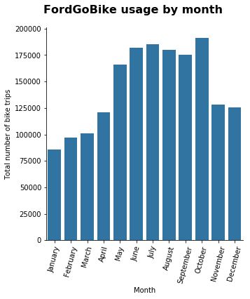

```python
g = sns.catplot(data=df_clean,x='start_time_month',kind='count',color=base_color)
g.set_axis_labels('Month','Total number of bike trips')
g.fig.suptitle('FordGoBike usage by month',y=1.05,fontsize=16,fontweight='bold')
g.set_xticklabels(rotation=75)
```

**Observation: The summer months and early-mid autumn are the most popular times to use the Ford GoBikes. October is the most popular month, with July as the second most popular, and June/August coming in closely as the third most popular months to use the bike system. The weather in San Francisco is best in the mid-late summer and usually stays sunny until returning to its usual foggy weather in the early winter months.**

**Now, let's look at the FordGoBike usage by weekday.**

```python
#Let's take a look at the statistics of the start_time_weekday
df_clean.start_time_weekday.describe()
```

```
count     1736572
unique          7
top           Tue
freq       301828
Name: start_time_weekday, dtype: object
```

**As you can see, the most frequently occuring weekday is Tuesday. Now let's visualize it by using a catplot.**

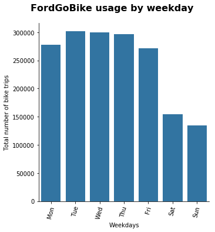

```python
weekday = ['Mon', 'Tue', 'Wed', 'Thu', 'Fri', 'Sat', 'Sun']
g = sns.catplot(data=df_clean,x='start_time_weekday',kind='count',color=base_color,order=weekday)
g.set_axis_labels('Weekdays','Total number of bike trips')
g.fig.suptitle('FordGoBike usage by weekday',y=1.05,fontsize=16,fontweight='bold')
g.set_xticklabels(rotation=75)
```

**Observation: The FordGoBike sharing system is mainly used during the weekdays, with Tuesday to Thursday as the most popular for clocking in most number of rides. The usage of the bikes seems to drop largely on Saturdays & Sundays indicating that the FordGoBike sharing system is used mainly as daily work commute during working days.**

**Now, let's look at the FordGoBike usage by hour.**

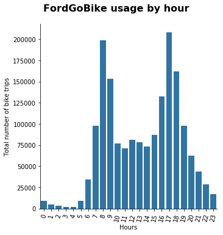

```python
g = sns.catplot(data=df_clean,x='start_time_hour',kind='count',color=base_color)
g.set_axis_labels('Hours','Total number of bike trips')
g.fig.suptitle('FordGoBike usage by hour',y=1.05,fontsize=16,fontweight='bold')
g.set_xticklabels(rotation=75)
```

**Observation: The above distribution is a bimodal distribution. The bikes saw the most usage during the morning hours of 8-9am, and in the evening hours of 5-6pm. This suggests that the bikes are being used primarily for work commutes.**

**Now, let's look at the FordGoBike system trip duration in seconds.**

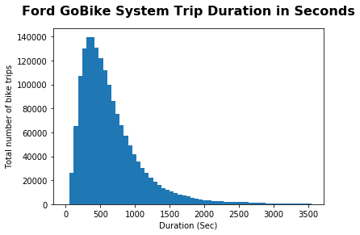

```python
bin_edges = np.arange(0,3600,60)
plt.hist(data=df_clean,x='duration_sec',bins=bin_edges)
plt.title("Ford GoBike System Trip Duration in Seconds", y=1.05, fontsize=16, fontweight='bold')
plt.xlabel('Duration (Sec)')
plt.ylabel('Total number of bike trips');
```

**Now, let's look at the FordGoBike system trip duration in minutes**

```python
#Let's take a look at the statistics of the duration_min
df_clean.duration_min.describe()
```

```
count    1.736572e+06
mean     1.247599e+01
std      3.310829e+01
min      1.000000e+00
25%      5.000000e+00
50%      9.000000e+00
75%      1.400000e+01
max      1.438000e+03
Name: duration_min, dtype: float64
```

```python
# Let's calculate average duration in minutes
df_clean.duration_min.mean()
```

```
12.475988902274135
```

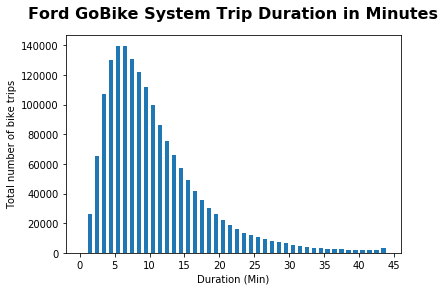

```python
bin_edges = np.arange(0, 45, 1)
ticks = [0, 5, 10, 15, 20, 25, 30,  35, 40, 45]
labels = ['{}'.format(val) for val in ticks]

plt.hist(data = df_clean, x = 'duration_min', bins = bin_edges, rwidth = 0.6);
plt.title("Ford GoBike System Trip Duration in Minutes", y=1.05, fontsize=16, fontweight='bold')
plt.xlabel('Duration (Min)')
plt.xticks(ticks, labels)
plt.ylabel('Total number of bike trips');
```

**Observation: As seen in the earlier visualization,the average trip is just under 12.5 minutes, with 75% of trips being under 14 minutes. Looking at the histogram, most rides fall in between the 3 - 11 minute range suggesting that people use the system for short commute travel.**

**Now, let's look at the FordGoBike usage by age**

```python
#Let's take a look at the statistics of the member_age
df_clean.member_age.describe()
```

```
count    1.736572e+06
mean     3.554417e+01
std      9.700772e+00
min      1.900000e+01
25%      2.800000e+01
50%      3.300000e+01
75%      4.100000e+01
max      6.600000e+01
Name: member_age, dtype: float64
```

```python
# Let's calculate average age of the user
df_clean.member_age.mean()
```

```
35.544169202313526
```

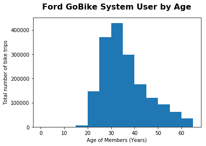

```python
bin_edges = np.arange(0, 66, 5)

plt.hist(data=df_clean,x='member_age',bins=bin_edges)
plt.title("Ford GoBike System User by Age", y=1.05, fontsize=16, fontweight='bold')
plt.xlabel('Age of Members (Years)')
plt.ylabel('Total number of bike trips');
```

**Observation: The average age of a user is around 35 years old. Earlier, in the cleaning section of this data set all users over the age of 66 were removed as they were cited as outliers. The above histogram shows the most of the users fall between the ages of 25 - 40 years, which is also the same age range of working adults.**

```python
gender = df_clean.member_gender.value_counts()
gender
```

```
Male      1273975
Female     435978
Other       26619
Name: member_gender, dtype: int64
```

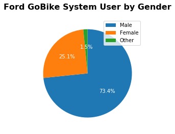

```python
plt.pie(gender, labels = gender.index, startangle = 90, autopct= '%1.1f%%', counterclock = False, textprops={'color':'white'});
#plt.axis('square');
plt.title('Ford GoBike System User by Gender', y=1.05, fontsize=16, fontweight='bold');
plt.legend()
```

### Of the features you investigated, were there any unusual distributions? Did you perform any operations on the data to tidy, adjust, or change the form of the data? If so, why did you do this?

> There was one unusal distribution for the member birth year, which in some cases was dated before 1900. Since 99% of the members are between 19 and 66 years, I removed users older than 66 to make the data tidy.  
> So far, the data reveals that adults in the average working age range of 25 - 40 years are the primary user base for the system using the bikes on their daily work commutes.

## Part V - Bivariate Exploration

> In this section, I investigate relationships between pairs of variables in the data mainly focusing the customer type for the analysis.

**Now, let's look at the user type split for FordGoBike sharing system**

```python
# Let's calculate the customer and subscriber split
customer = df_clean.query('user_type == "Customer"')['bike_id'].count()
subscriber = df_clean.query('user_type == "Subscriber"')['bike_id'].count()


customer_prop = customer / df_clean['bike_id'].count()
subscriber_prop = subscriber / df_clean['bike_id'].count()
```

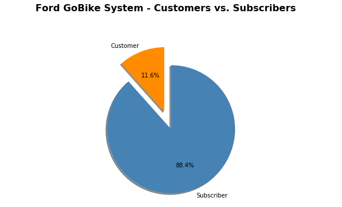

```python
plt.figure(figsize=[10,5])

labels = ['Customer','Subscriber']
sizes = [customer_prop,subscriber_prop]
explode = (0,0.3)
colors = ['darkorange','steelblue']

plt.pie(sizes,explode=explode,labels=labels,colors=colors, autopct='%1.1f%%',shadow=True,startangle=90)
plt.axis('equal')
plt.suptitle('Ford GoBike System - Customers vs. Subscribers', y=1.05, fontsize=16, fontweight='bold');
```

**Now, let's visualize a barchart for the above split.**

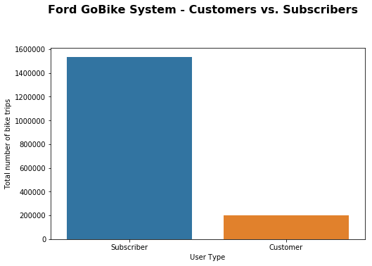

```python
# Plotting a barchart

plt.figure(figsize=[8,5])

g = sns.countplot(data=df_clean,x='user_type',order=df_clean.user_type.value_counts().index)
g.set_xlabel('User Type')
g.set_ylabel('Total number of bike trips')
plt.suptitle('Ford GoBike System - Customers vs. Subscribers', y=1.05, fontsize=16, fontweight='bold');
```

**Observation: The bike sharing system is mainly used by subscribers (88%) than ocassional riders (12%).**

**Now, I am gonna visualize the bike renting trends sorted by monthly,daily,hourly for each user type.**

**Firstly, let's look at the monthly usage of FordGoBike bikes as per user type**

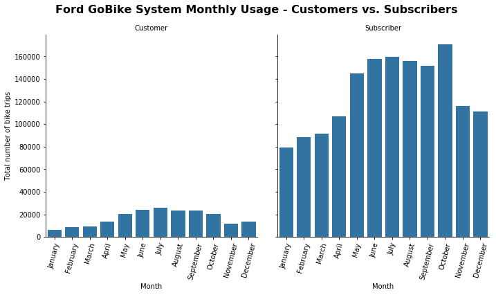

```python
g = sns.catplot(data=df_clean,x='start_time_month',col='user_type',color=base_color,sharey=True,kind='count')
g.set_axis_labels('Month','Total number of bike trips')
g.set_titles("{col_name}")
plt.suptitle('Ford GoBike System Monthly Usage - Customers vs. Subscribers', y=1.05, fontsize=16, fontweight='bold');
g.set_xticklabels(rotation=75);
```

**Observation: Winter months are the worst for the bike sharing system for both groups what can be determined by the harsher weather.**

For **Customers,** the bike renting is high in demand around summertime, reaching its peak in July. Customers are most probably tourists, or the occasional riders who visit the Bay Area.

For **Subscribers,** the highest demand is from May till October, reaching it's peak in October. I think the subscribers are most probably regular riders using bikes for their daily commute preferably for work due to the age range.

**Now, let's look at the weekly usage of FordGoBike bikes as per user type.**

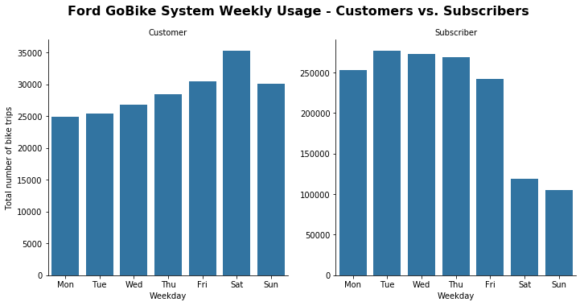

```python
weekday = ['Mon','Tue','Wed','Thu','Fri','Sat','Sun']
g = sns.catplot(data=df_clean,x='start_time_weekday',col='user_type',color=base_color,order=weekday,sharey=False,kind='count')
g.set_axis_labels('Weekday','Total number of bike trips')
g.set_titles("{col_name}")
plt.suptitle('Ford GoBike System Weekly Usage - Customers vs. Subscribers', y=1.05, fontsize=16, fontweight='bold');
```

**Observation:**There is a different trend for days on which customers and subscribers rent bikes.

For **Customers,** Customers have a relatively low usage of the bike share system with a small increase on the weekends.Customers are most probably occasional riders and tourists who use the bike sharing system on holidays or weekend trips.

For **Subscribers,** Subscribers have a steadily high usage on weekdays, with a sharp decline on the weekends. Subscribers are most probably daily work/school commuters who use the system throughout the week.

**Let's also plot a line-plot to get a better understanding of the relationship.**

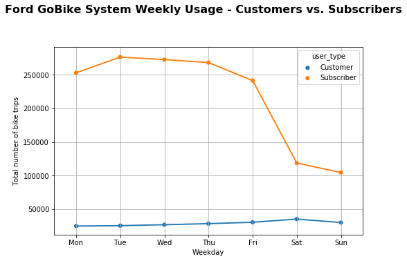

```python
plt.figure(figsize=(8, 5))

df_clean_user_week = df_clean.groupby(['start_time_weekday', 'user_type']).size().reset_index()

weekday = ['Mon', 'Tue', 'Wed', 'Thu', 'Fri', 'Sat', 'Sun']

ax = sb.pointplot(data=df_clean_user_week, x='start_time_weekday', y=0, hue = 'user_type', scale=.7, order = weekday);

plt.suptitle('Ford GoBike System Weekly Usage - Customers vs. Subscribers', y=1.05, fontsize=16, fontweight='bold');
plt.xlabel('Weekday')
plt.ylabel('Total number of bike trips');
plt.grid()
```

**Observation: The point plot above is a tremendous visual showing the sharp contrast between Customers and Subscribers as seen in the barcharts.**

**Now, let's look at the hourly usage of FordGoBike bikes as per user type.**

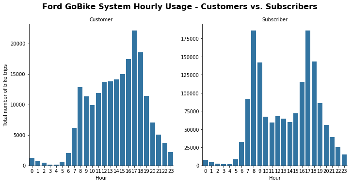

```python
g = sns.catplot(data=df_clean,x='start_time_hour',col='user_type',color=base_color,sharey=False,kind='count')
g.set_axis_labels('Hour','Total number of bike trips')
g.set_titles("{col_name}")
plt.suptitle('Ford GoBike System Hourly Usage - Customers vs. Subscribers', y=1.05, fontsize=16, fontweight='bold');
```

**Observation:**There is a different trend for what time of the day at which customers and subscribers rent bikes.

For **Customers,** Customers use bikes mainly between 4 pm - 6 pm, reaching the renting peak around 5pm.

For **Subscribers,** Subscribers use the bikes at around 8-9am and around 5-6pm presumably for their work commute.

**Now, let's look at the trip duration variation of FordGoBike bikes as per user type.**

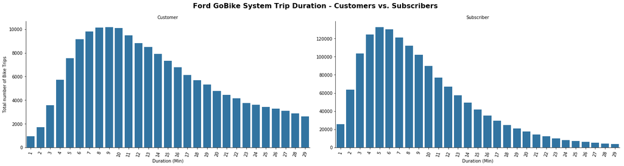

```python
data = df_clean.query('duration_min < 30')

graph = sb.catplot(data=data, x = 'duration_min', col='user_type', kind='count', sharey = False, color = base_color, height=5, aspect=2);

graph.set_axis_labels('Duration (Min)', 'Total number of Bike Trips')
graph.set_titles('{col_name}')

graph.fig.suptitle('Ford GoBike System Trip Duration - Customers vs. Subscribers', y=1.05, fontsize=16, fontweight='bold');
graph.set_xticklabels(rotation=75);
```

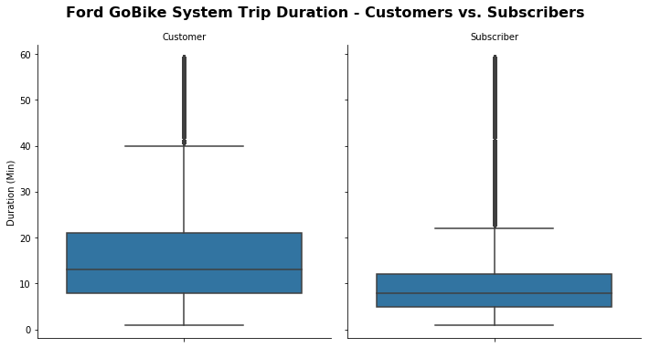

```python
# Let's plot a box plot to better understand the relationship
data = df_clean.query('duration_min < 60')
g = sb.catplot(data=data,y='duration_min',col='user_type',kind='box',color=base_color)
g.set_titles(col_template = '{col_name}')
g.set_axis_labels("", "Duration (Min)")
g.fig.suptitle('Ford GoBike System Trip Duration - Customers vs. Subscribers', y=1.05, fontsize=16, fontweight='bold');
```

**Now, let's look at the age distribution of users of FordGoBike bikes as per user type.**

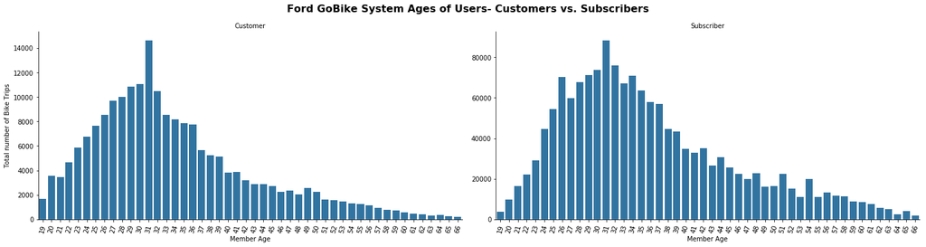

```python
graph = sb.catplot(data=df_clean, x = 'member_age', col='user_type', kind='count', sharey = False, color = base_color, height=5, aspect=2);

graph.set_axis_labels('Member Age', 'Total number of Bike Trips')
graph.set_titles('{col_name}')

graph.fig.suptitle('Ford GoBike System Ages of Users- Customers vs. Subscribers', y=1.05, fontsize=16, fontweight='bold');
graph.set_xticklabels(rotation=75);
```

### Talk about some of the relationships you observed in this part of the investigation. How did the feature(s) of interest vary with other features in the dataset?

> Adding the user type to the analysis showed different usage behaviours between customers and subscribers. As mentioned above, customers are casual riders most probably tourists, or students on a vacation, who rent bikes mainly in summertime (the peak in July), more often during weekends than weekdays and they rent bikes more often in the evening hours. Subscribers are daily commuters or full time students who use the system during weekdays, and mostly for shorter distances. They mainly rent bikes before and after a typical work or school day (8-9am and 5-6pm).

### Did you observe any interesting relationships between the other features (not the main feature(s) of interest)?

> There is a difference in the trip duration between customers and subscribers. Customers trips are usually longer than for subscribers, most probably due to the fact they prefer bike rides around weekends in summertime, which may be for longer trips around the surrounding area. Subscribers on the other hand use the system mainly for short commute purposes so they rather prefer quick rides to and from work/school.

## Part VI - Multivariate Exploration

> In this section, I will further explore the Ford GoBike data by creating plots of three or more variables.

**Let's see the gender distribution for the user type of FordGoBike.**

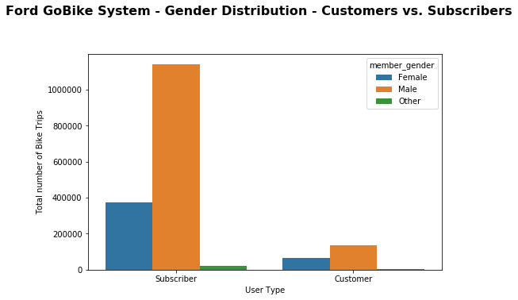

```python
plt.figure(figsize = [8, 5])
g = sns.countplot(data=df_clean,x='user_type',hue='member_gender',order=df_clean.user_type.value_counts().index)
g.set_xlabel('User Type')
g.set_ylabel('Total number of Bike Trips');
plt.suptitle('Ford GoBike System - Gender Distribution - Customers vs. Subscribers', y=1.05, fontsize=16, fontweight='bold');
```

**Observation:** In general, males are using the system more often than females and others (the registration system allows you to choose 'Other' as a gender). However, the ratio is much smaller between males and females for **Customers**(more ore less 2:1) than for **Subscribers**.

**Now,let's explore if gender affects the way the bike system is used within a year, weekdays and hours of the day.**

**Firstly, let's look at the monthly usage of FordGoBike bikes as per user type & gender**

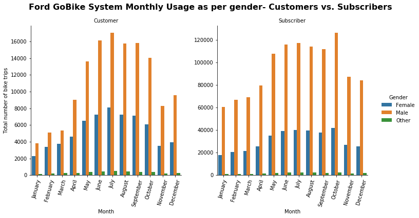

```python
g = sns.catplot(data=df_clean,x='start_time_month',col='user_type',hue='member_gender',sharey=False,kind='count')
g.set_axis_labels('Month','Total number of bike trips')
g.set_titles("{col_name}")
g._legend.set_title('Gender')
plt.suptitle('Ford GoBike System Monthly Usage as per gender- Customers vs. Subscribers', y=1.05, fontsize=16, fontweight='bold');
g.set_xticklabels(rotation=75);
```

**Observation:** The trend is kinda similar for both males and females.  
For **Customers,** the highest demand is around summertime, reaching its peak in July; For **Subscribers,** the highest demand is from May till October, reaching it's peak in October.  
Suprisingly, for **Customers** there are quite a lot of females using the system between January and March in comparison to males - the ratio is much smaller than for the rest of the year.

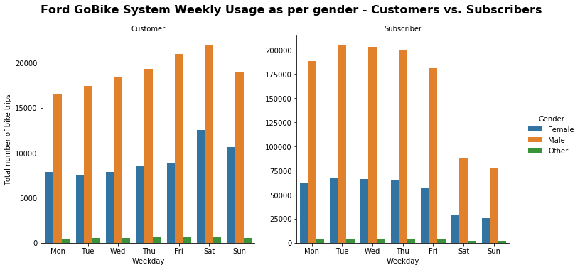

```python
weekday = ['Mon','Tue','Wed','Thu','Fri','Sat','Sun']
g = sns.catplot(data=df_clean,x='start_time_weekday',col='user_type',hue='member_gender',order=weekday,sharey=False,kind='count')
g.set_axis_labels('Weekday','Total number of bike trips')
g.set_titles("{col_name}")
g._legend.set_title('Gender')
plt.suptitle('Ford GoBike System Weekly Usage as per gender - Customers vs. Subscribers', y=1.05, fontsize=16, fontweight='bold');
```

**Observation:** As in the previous section, the trend is very similar for males and females:  
For **Customers,** the highest demand is often during weekends than weekdays (although the jump in bike used on weekends is much higher for females than for males).  
For **Subscribers** the demand is mainly within the week.

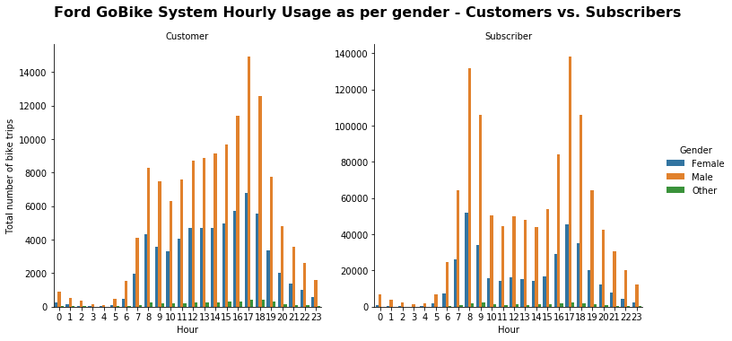

```python
g = sns.catplot(data=df_clean,x='start_time_hour',col='user_type',hue='member_gender',sharey=False,kind='count')
g.set_axis_labels('Hour','Total number of bike trips')
g.set_titles("{col_name}")
g._legend.set_title('Gender')
plt.suptitle('Ford GoBike System Hourly Usage as per gender - Customers vs. Subscribers', y=1.05, fontsize=16, fontweight='bold');
```

**Observation:** During the day, both males and females use the system the same way.  
For **Customers,** they use bikes mainly between 8 am - 7 pm.  
For **Subscribers,** they use the system at around 8-9am and 5-6pm when they go and come back from work. One thing to notice here is that, there's a major downfall of female users especially during the morning hours.

[figure not shown]

```python
g = sb.catplot(data=data, x='user_type', y="duration_min", hue="member_gender", kind="violin");

g.set_axis_labels("User Type", "Trip Duration (Min)")
g._legend.set_title('Gender')
g.fig.suptitle('Ford GoBike System - Trip Duration (Min) Per User Type and Gender', y=1.05, fontsize=16, fontweight='bold');
```

**Observation:** In both cases, females take longer trips (measured in mins) than males and other genders. The difference is more visible for customers (~13 min for males and other vs ~15 for females) than for subscribers (the difference is quite small).

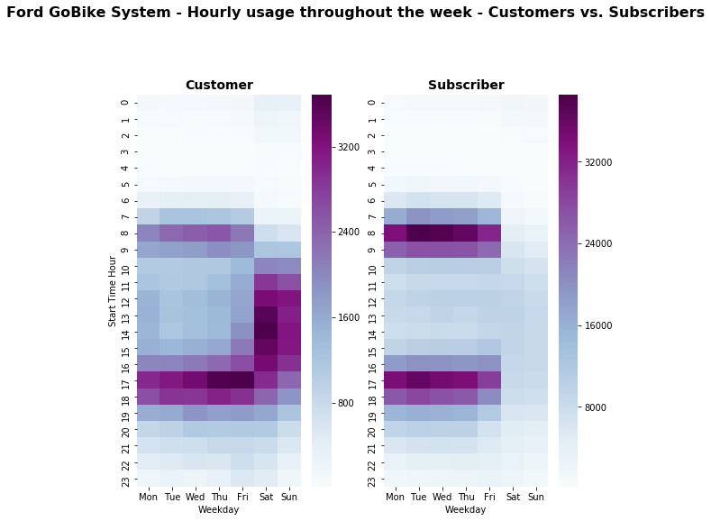

```python
# Let's set the weekday order
df_clean['start_time_weekday'] =  pd.Categorical(df_clean['start_time_weekday'],
                                                categories=['Mon','Tue','Wed','Thu','Fri','Sat', 'Sun'],
                                                ordered=True)
plt.figure(figsize=(9,8))
plt.suptitle('Ford GoBike System - Hourly usage throughout the week - Customers vs. Subscribers', y=1.05, fontsize=16, fontweight='bold');


#Plotting a heatmap for Customers
plt.subplot(1,2,1)
df_customer = df_clean.query('user_type == "Customer"').groupby(["start_time_hour", "start_time_weekday"])["bike_id"].size().reset_index()
df_customer = df_customer.pivot('start_time_hour','start_time_weekday','bike_id')
sns.heatmap(df_customer,cmap='BuPu')
plt.title("Customer", y=1.015, fontsize=14, fontweight='bold')
plt.xlabel('Weekday')
plt.ylabel('Start Time Hour');


#Plotting a heatmap for Subscribers
plt.subplot(1,2,2)
df_subscriber = df_clean.query('user_type == "Subscriber"').groupby(["start_time_hour", "start_time_weekday"])["bike_id"].size().reset_index()
df_subscriber = df_subscriber.pivot('start_time_hour','start_time_weekday','bike_id')
sns.heatmap(df_subscriber,cmap='BuPu')
plt.title("Subscriber", y=1.015, fontsize=14, fontweight='bold')
plt.xlabel('Weekday')
plt.ylabel('');
```

**Observation:** The plot perfectly summarizes the different trends altogether for customers and subscribers I was visualizing in the above plots.

**Customers ride the FordGoBikes more often on weekends:**

- Weekdays(Mon-Fri): Most rides happen around 8-9am and 5-6pm with the peak on Fridays around 5pm.
- Weekends(Sat-Sun): Most rides happen between 11am - 6pm with the peak on Saturdays around 1pm - 2pm.

**Subscribers use the bike sharing system mostly on weekdays:**

- Weekdays(Mon-Fri): Most rides happen around 8-9am and 5-6pm with the peak on Tuesdays around 8am.
- Weekends(Sat-Sun): The bikes are hardly rented during the weekends as most of them use the bikes for daily work commute.

### Talk about some of the relationships you observed in this part of the investigation. Were there features that strengthened each other in terms of looking at your feature(s) of interest?

> This section enhanced the previous topics of data exploration through different visuals and adding in more variables to compare to other variables. Plotting a heatmap of demand of the bikes throughout the day on a weekly basis shed a new light on the time based discussion on when and what time each user group uses the bike sharing system. Plotting the bike trips throughout the day and bike trips within the weekdays separately gave the impression that the demand for bikes is quite high throughout the day with a peak around 5pm which is not entirely true. The trend within weekdays for customers follows the one for subscribers who rent bikes mainly around commute hours (8-9am and 5-6pm). For customers, as depicted in bivariate explorations, most of the trips happen on weekends but mainly between 11am - 6pm with the peak on Saturdays around 2pm, what was previously not visible only possible through the multivariate exploration. By adding gender as the hue for each plot, we got a better understanding of the gender distribution for the usage of the FordGoBikes.

### Were there any interesting or surprising interactions between features?

> Nothing out of the blue here. It was interesting to note the sharp monthly difference for Males vs. Females vs. Other, and how close the Female count got to the Male Customer count in January through March. This may be a potential loss of possible Customers converting to Subscribers.Moreover Females take longer trips than Males and others.